# A Small List of Environmental Types have the Highest Consequenses to Human and Economic Health

Author: Cary Correia Coursera: Data Science- Reproducible Research: Peer Assessment 2

## Synopsis

The purpose of this assignment was to explore the NOAA Storm Database and answer basic questions with regards to severe weather events and their effects on human and economic health.

## Data Processing

Before starting the data processing it was necessary to setup the workspace. A file folder was setup to house all the project documents and code.

```r
setwd('/Users/carycorreia/Documents/Exploratory_Data_Project1/RepData_PeerAssessment2')
```

The data is a basic 'csv' file that has been zipped into a 'bz2'file. This file was easily handled with a read.table function.

```r
data<-read.table('repdata-data-StormData.csv.bz2', header=TRUE, sep=",")
initial.load<-nrow(data)
```

At this point in the process there is a very large data set with 902297 data points. This file size proved to be too large for my system to handle so I decided to reduce the data.

The following code trims the data set down to a manageable size:

```r
## Remove unnecessary data from file
data<-data[!(data$FATALITIES==0 & data$INJURIES==0 & data$PROPDMG==0 & data$CROPDMG==0),]
final.load<-nrow(data)
```

The data rows removed by definition of the fact that all 4 categories had 0 values. The final dataset is now 254633 records.

The next step in processing was to alter the **EVTYPE** field. A simple look at the field showed numerous issues ranging from typos, inconsistencies and irrelevant codings.

To prep for cleanup the following code was run:

```r
##  Get unique list of EVTYPEs then duplicate the header
##  these steps are necessary because i dont want to alter the orig column names
evt<-as.data.frame(unique(data$EVTYPE))
evt$recode<-unique(data$EVTYPE)
names(evt)<-c("raw_EVTYPE", "original_EVTYPE")

# transform the EVTYPE to lower case
evt$raw_EVTYPE<-tolower(evt$raw_EVTYPE)
```

Then through a series of iterative search and replaces I managed to put together 48 rules that used keyword or letter sequence matches. These search terms were used along with the **grepl()** function to recode the column and make it into a useable format. Note I decided to use the 48 rules directly from the field guide and that the **evt** dataframe is a temporary construct used to determine the cleaned verison of the EVTYPE field.

The following code initiates the cleanup of the duplicated column:

```r
# Build storm data event matrix--> this code creates a new column and scans for a match to my keywords...
# if a keyword matches a 1 goes into the field:  note the order of the fields is important in case i get multiple hits

evt$AstronomicalLowTide<-as.integer(grepl(c("astronomical low tide"), evt$raw_EVTYPE))
evt$LakeshoreFlood<-as.integer(grepl(c("lakeshore flood"), evt$raw_EVTYPE))
evt$CoastalFlood<-as.integer(grepl(c("coastal flood"), evt$raw_EVTYPE))
evt$FlashFlood<-as.integer(grepl(c("flash flood|flash floooding"), evt$raw_EVTYPE))
evt$Flood<-as.integer(grepl(c("flood|fld|urban|small stream"), evt$raw_EVTYPE))
evt$Lightning<-as.integer(grepl(c("lightning|lighting|ligntning"), evt$raw_EVTYPE))
evt$Tornado<-as.integer(grepl(c("torn|whirl"), evt$raw_EVTYPE))
evt$MarineThunderstormWind<-as.integer(grepl(c("marine thunderstorm wind"), evt$raw_EVTYPE))
evt$ThunderstormWind<-as.integer(grepl(c("thunder|tstm|tunder|thundes|thudder|thundeer|thuner|thuder"), evt$raw_EVTYPE))
evt$HurricaneTyphoon<-as.integer(grepl(c("hurricane|typhoon|floyd"), evt$raw_EVTYPE))
evt$Avalanche<-as.integer(grepl(c("aval"), evt$raw_EVTYPE))
evt$Blizzard<-as.integer(grepl(c("blizz"), evt$raw_EVTYPE))
evt$ExtremeCold_WindChill<-as.integer(grepl(c("extreme cold|wind chill|record low|low temp|windchill|cool|hypo|hyper|record cold"), evt$raw_EVTYPE))
evt$FunnelCloud<-as.integer(grepl(c("funnel cloud|funnel|wall cloud"), evt$raw_EVTYPE))
evt$DenseFog<-as.integer(grepl(c("dense fog|fog|vog"), evt$raw_EVTYPE))
evt$HeavySnow<-as.integer(grepl(c("heavy snow|record snow|excessive snow|record winter snow|snow accumulation|snowstorm|heavy wet snow|record may snow|snow squall"), evt$raw_EVTYPE))
evt$IceStorm<-as.integer(grepl(c("ice storm|ice|glaze"), evt$raw_EVTYPE))
evt$Sleet<-as.integer(grepl(c("sleet"), evt$raw_EVTYPE))
evt$FrostFreeze<-as.integer(grepl(c("frost|freeze|freezing|icy roads"), evt$raw_EVTYPE))
evt$Cold_WindChill<-as.integer(grepl(c("cold"), evt$raw_EVTYPE))
evt$DebrisFlow<-as.integer(grepl(c("land|mud|rock|landslump"), evt$raw_EVTYPE))
evt$DenseSmoke<-as.integer(grepl(c("dense smoke|smoke"), evt$raw_EVTYPE))
evt$DustDevil<-as.integer(grepl(c("dust devil|devel"), evt$raw_EVTYPE))
evt$DustStorm<-as.integer(grepl(c("dust"), evt$raw_EVTYPE))
evt$Waterspout<-as.integer(grepl(c("waterspout|water spout|wayterspout"), evt$raw_EVTYPE))
evt$Drought<-as.integer(grepl(c("drought|dry|driest"), evt$raw_EVTYPE))
evt$ExcessiveHeat<-as.integer(grepl(c("excessive heat|record high|high temp|record warmth"), evt$raw_EVTYPE))
evt$Heat<-as.integer(grepl(c("heat|warm|warmth|hot spell|hot"), evt$raw_EVTYPE))
evt$FreezingFog<-as.integer(grepl(c("freezing fog"), evt$raw_EVTYPE))
evt$MarineHail<-as.integer(grepl(c("marine hail"), evt$raw_EVTYPE))
evt$Hail<-as.integer(grepl(c("hail"), evt$raw_EVTYPE))
evt$StormSurge_Tide<-as.integer(grepl(c("surge|high tide|high sea|surf|high waves|high water|swells|rogue|rough sea|heavy sea"), evt$raw_EVTYPE))
evt$HeavyRain<-as.integer(grepl(c("heavy rain|record rainfall|heavy precip|rainstorm|burst|torrential|hvy rain|excessive rain|shower|rain (heavy) |wet microburst"), evt$raw_EVTYPE))
evt$HighSurf<-as.integer(grepl(c("high surf"), evt$raw_EVTYPE))
evt$LakeEffectSnow<-as.integer(grepl(c("effect snow|heavy lake snow"), evt$raw_EVTYPE))
evt$RipCurrent<-as.integer(grepl(c("rip current"), evt$raw_EVTYPE))
evt$Seiche<-as.integer(grepl(c("seiche"), evt$raw_EVTYPE))
evt$MarineStrongWind<-as.integer(grepl(c("marine strong wind|coastal storm|coastalstorm"), evt$raw_EVTYPE))
evt$StrongWind<-as.integer(grepl(c("strong wind|turbulence|storm force wind|dry microburst|microburst"), evt$raw_EVTYPE))
evt$TropicalDepression<-as.integer(grepl(c("tropical depression"), evt$raw_EVTYPE))
evt$TropicalStorm<-as.integer(grepl(c("tropical storm"), evt$raw_EVTYPE))
evt$Tsunami<-as.integer(grepl(c("tsunami"), evt$raw_EVTYPE))
evt$VolcanicAsh<-as.integer(grepl(c("volcan"), evt$raw_EVTYPE))
evt$Wildfire<-as.integer(grepl(c("wildfire|wild fires|wild/forest fire|grass|forest fire|brush|red flag"), evt$raw_EVTYPE))
evt$WinterStorm<-as.integer(grepl(c("winter storm"), evt$raw_EVTYPE))
evt$WinterWeather<-as.integer(grepl(c("winter weather|wintry|winter mix|wintery"), evt$raw_EVTYPE))
evt$MarineHIghWind<-as.integer(grepl(c("marine high wind"), evt$raw_EVTYPE))
evt$HighWind<-as.integer(grepl(c("high wind|high winds|high  winds|gusty|gustnado|gradient|wind|non tstm|non-tstm"), evt$raw_EVTYPE))
##
## This code will summarize the number of successful (1 perfect match) matches
#run count seq to determine 1's and multi's:
evt$count<-rowSums(Filter(is.integer, evt))

#split off the matrix of 1's= easy, 2-4 = orderRule, 0=misc
easy<-evt[evt$count==1,]; easyno<-nrow(easy)
order<-evt[evt$count>1,]; orderno<-nrow(order)
misc<-evt[evt$count==0,]; miscno<-nrow(misc)
```

After running this code we had the following success rates:

- 276 -these matches mean these rows don't need any further touches
- 182-these matches mean the field could have multiple categories
- 30 -these matches mean we could not link them to one of the 48 EVTYPES

Upon inspection the 30 misc fields were not meaningful to the rest of the analysis. The 182 datarows were handled in the following way. When I created the initial EVTYPE replacement rules I ordered the rules from best match to worst match. Then when my match rountine scanned the EVTYPES fields in my file it would stop on the first (and best) match.

The following match routine is used to find the first best match:

```r
#determine row where we have an EVALTYPE match
columns<-c(colnames(evt))
for(i in 1:nrow(evt)){
        evt$check[i]<-match("1", evt[i,3:50])
}
#pop in the corrected name
#note NA's are the misc dataframe--> these are EVTYPEs that we choose to ignore
evt$recode<-c(columns[evt$check[1:nrow(evt)]+2])

# merge/vlookup the recoded variable back into the main databrick
data<-merge(x=data, y=evt, by.x="EVTYPE", by.y="original_EVTYPE")
```

At the end of this routine the record with multiple EVTYPES has only 1 setting. The final adjustments are then rewritten back into the dataset.

The next step involves coding the time period for the dataset. There were 4 main timeframes that had the most meaning and I wanted to be able to analyze the data from a time perspective to look for any time based shifts.

The following code processes sets the date and creates the Period and fields for Crop and Property damages:

```r
## Let's put in a count into dataset so we can count up during the aggregation process
data$count2<-rep(1,nrow(data))
## Let's create a column to isolate the 4 time periods of interest

## First-let's format the date columns
data$BGN_DATE<-as.Date(strptime(data$BGN_DATE, "%m/%d/%Y %H:%M:%S"))
data$period<-as.numeric(format(data$BGN_DATE, "%Y"))

data$period2<- ifelse(data$period<1955, '1950-1954',
                        ifelse(data$period<1993,'1955-1992',
                                ifelse(data$period<1996,'1993-1995',
                                        ifelse(data$period<2014,'1996-Present','unknown'))))

## Need to calculate CROPDMG and PROPDMG
data$crop.cost<-ifelse(!is.na(data$CROPDMG),
                  ifelse(data$CROPDMGEXP=='K', data$CROPDMG*1000,
                         ifelse(data$CROPDMGEXP=='M', data$CROPDMG*1000000,
                                ifelse(data$CROPDMG=='B', data$CROPDMG*1000000000, 0))))
data$prop.cost<-ifelse(!is.na(data$PROPDMG),
                       ifelse(data$PROPDMGEXP=='K', data$PROPDMG*1000,
                              ifelse(data$PROPDMGEXP=='M', data$PROPDMG*1000000,
                                     ifelse(data$PROPDMG=='B', data$PROPDMG*1000000000, 0))))
```

At this point in the process the data table now has recoded variables for the time period and for the crop damage and property damage fields (both crop and property are set to $'s)

Now that the EVTYPE's have been fixed and we have fields in place for our plots, we have to aggregate the data by EVTYPE I decided to use the tapply function with the sum command to build up my tables.

The following code shows the tapply function and then the process where I reshaped the data into a long format. Eventually I created one Final.Table to house the completed aggregations:

```r
## Lets' build the aggregated data so we can take a look at the Y measures by the EVTYPE and Period
## Fatalities summarized
        fatal.agg<-as.data.frame(tapply(data$FATALITIES, list(evtype=data$recode, period=data$period2), sum))
        EF.kill<-rownames(fatal.agg); fatal.agg$EVTYPE<-EF.kill
## Injuries   summarized
        injuries.agg<-as.data.frame(tapply(data$INJURIES, list(evtype=data$recode, period=data$period2), sum))
        EF.injuries<-rownames(injuries.agg); injuries.agg$EVTYPE<-EF.injuries
## crop costs summarized
        crop.agg<-as.data.frame(tapply(data$crop.cost, list(evtype=data$recode, period=data$period2), sum))
        EF.crops<-rownames(crop.agg); crop.agg$EVTYPE<-EF.crops
## prop.costs summarized
        prop.agg<-as.data.frame(tapply(data$prop.cost, list(evtype=data$recode, period=data$period2), sum))
        EF.props<-rownames(prop.agg); prop.agg$EVTYPE<-EF.props

# let's reshape the data to fit this into 1 table
library(reshape)
fatal<-reshape(fatal.agg,
               varying=c('1950-1954', '1955-1992', '1993-1995', '1996-Present'),
               v.names="Fatal.count",
               timevar="Period",
               times=c('1950-1954', '1955-1992', '1993-1995', '1996-Present'),
               direction="long")
injure<-reshape(injuries.agg,
               varying=c('1950-1954', '1955-1992', '1993-1995', '1996-Present'),
               v.names="injure.count",
               timevar="Period",
               times=c('1950-1954', '1955-1992', '1993-1995', '1996-Present'),
               direction="long")
crops<-reshape(crop.agg,
                varying=c('1950-1954', '1955-1992', '1993-1995', '1996-Present'),
                v.names="Crops.DMG",
                timevar="Period",
                times=c('1950-1954', '1955-1992', '1993-1995', '1996-Present'),
                direction="long")
props<-reshape(prop.agg,
                varying=c('1950-1954', '1955-1992', '1993-1995', '1996-Present'),
                v.names="Propety.DMG",
                timevar="Period",
                times=c('1950-1954', '1955-1992', '1993-1995', '1996-Present'),
                direction="long")
## Let's combine the data into 1 large table
Final.Table2<-fatal
Final.Table2$Injuries<-injure$injure.count
Final.Table2$CropDamage<-crops$Crops.DMG
Final.Table2$PropsDamage<-props$Propety.DMG
```

At the end of this process we have a **Final.Table2** data frame which houses the complete data aggregations.

The final data process step is to prep the data into a format that will facilitate our graphical analysis. For this project I decided to use Pareto plots (ordered bar charts)….so the following steps will create structures to faciliate that.

The following code will reprocess the data into 4 separate pieces for our two panel plots. In order to create the ordered bar chart it was necessary to put the EVTYPE into numerical order(based on the 4 output values) not alphabetical.

Also I decided to chop down the pareto's to highlight the top EVTYPES because with 48 separate types and hardly any values it made no sense to show the entire list.

```r
# sort the 4 facts for our pareto charts
fatalact <- subset(Final.Table2, select=c("EVTYPE", "Period", "Fatal.count"))
fatalact$Fatal.count<-as.numeric(fatalact$Fatal.count)
fatalsort <-fatalact[ with(fatalact, order(Period,-Fatal.count, EVTYPE), na.last=FALSE),]
fatalsort$top<-c(rep(1:46, 4))
## Lets Just Look at the Top 10 EVT's
fatTop<-subset(fatalsort, fatalsort$top<11)

injuriesact <- subset(Final.Table2, select=c("EVTYPE", "Period", "Injuries"))
injuriesact$Injuries<-as.numeric(injuriesact$Injuries)
injsort <-injuriesact[ with(injuriesact, order(Period,-Injuries, EVTYPE), na.last=FALSE),]
injsort$top<-c(rep(1:46, 4))
## Lets Just Look at the Top 10 EVT's
injTop<-subset(injsort, injsort$top<11)

cropsact <- subset(Final.Table2, select=c("EVTYPE", "Period", "CropDamage"))
cropsact$CropDamage<-as.numeric(cropsact$CropDamage)
cropssort <-cropsact[ with(cropsact, order(Period,-CropDamage, EVTYPE), na.last=FALSE),]
cropssort$top<-c(rep(1:46, 4))
## Lets Just Look at the Top 10 EVT's
cropTop<-subset(cropssort, cropssort$top<11)

propsact <- subset(Final.Table2, select=c("EVTYPE", "Period", "PropsDamage"))
propsact$PropsDamage<-as.numeric(propsact$PropsDamage)
propssort <-propsact[ with(propsact, order(Period,-PropsDamage, EVTYPE), na.last=FALSE),]
propssort$top<-c(rep(1:46, 4))
## Lets Just Look at the Top 10 EVT's
propTop<-subset(propssort, propssort$top<11)
```

## Across the United States, which types of events (as indicated in the EVTYPE variable)

## are most harmful with respect to population health?

The following code is used to create a panel plot (two ggplots bolted together). To answer the question of population health I decided to bolt the two pareto's for Injuries and Fatalities together.

### Panel Plot 1: Fatalities and Injuries by Environmental Factor between 1950 and Present

Note: there are quite a few NA fields in the final tables because there was no data in many of the time periods by EVTYPE. ggplot takes cares of this by removing them and then it warns you that the missing fields were removed from the plot.

```
## Warning: Removed 9 rows containing missing values (position_stack).
## Warning: Removed 7 rows containing missing values (position_stack).
## Warning: Removed 9 rows containing missing values (position_stack).
## Warning: Removed 7 rows containing missing values (position_stack).
```

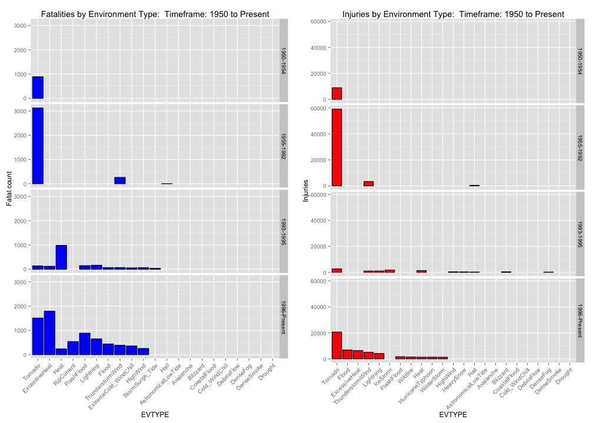

```r
#Create Panel Plot 1: Fatalities and Injuries by EVTYPE
library(ggplot2)
cropssort$group<-as.factor(cropssort$Period)
require(gridExtra)
fatTop<-transform(fatTop, EVTYPE=reorder(EVTYPE, -Fatal.count))   ## reorder the data
plot1<-ggplot(fatTop, aes(EVTYPE, Fatal.count))+
        geom_bar(stat="identity", color="black", fill="blue")+
        facet_grid(Period ~.) +
        theme(legend.position = "none", axis.text.x=element_text(size=10, angle = 45, hjust = 1))+
        ggtitle("Fatalities by Environment Type:  Timeframe: 1950 to Present")

injTop<-transform(injTop, EVTYPE=reorder(EVTYPE, -Injuries))   ## reorder the data
plot2<-ggplot(injTop, aes(EVTYPE, Injuries))+
        geom_bar(stat="identity", color="black", fill="red")+
        facet_grid(Period ~.) +
        theme(legend.position = "none", axis.text.x=element_text(size=10, angle = 45, hjust = 1))+
        ggtitle("Injuries by Environment Type:  Timeframe: 1950 to Present")

grid.arrange(plot1, plot2, ncol=2)
```

### Panel Plot 1: Fatalities and Injuries by Environmental Factors between 1950 and Present

## Analysis:

According to our FAQ the periods between 1950 to 1995 were fairly sparse when it came to data collection. Only Tornadoes were measured in the 1950-1954 time period as confirmed by our panel plot #1.

In the time period for 1955-1992 the data shows that there were in addition to Tornado's there were hail and thunderstorms added to the list. It is also interesting to note that in this time period they had the highest deaths and injuries from Tornados.(~3000 Fatalties, ~60,000 Injuries). This is the highest period for both Fatalities and Injuries in any of our 4 time eras.

During the 1993-1995 period there was a marked decrease in Tornados. Also a few more environmental criteria were added to the list but the data again was very sparse and may not have been indicative of true weather patterns (see FAQ notes).

In the latest period we can see that both Injuries and Fatalites track very closely to the Environmental types below:

## Across the United States, which types of events have the greatest economic consequences?

The following code is used to create a panel plot (two ggplots bolted together).

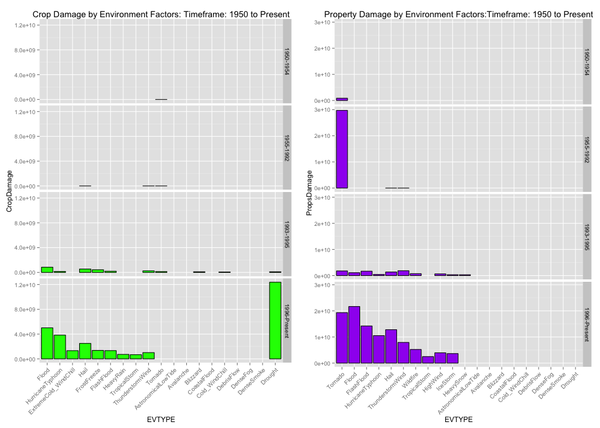

```r
#Create Panel Plot 2: CropDamage and PropetyDamage by EVTYPE
cropTop<-transform(cropTop, EVTYPE=reorder(EVTYPE, -CropDamage))   ## reorder the data
plot1<-ggplot(cropTop, aes(EVTYPE, CropDamage))+
        geom_bar(stat="identity", color="black", fill="Green")+
        facet_grid(Period ~.) +
        theme(legend.position = "none", axis.text.x=element_text(size=10, angle = 45, hjust = 1))+
        ggtitle("Crop Damage by Environment Factors: Timeframe: 1950 to Present")

propTop<-transform(propTop, EVTYPE=reorder(EVTYPE, -PropsDamage))   ## reorder the data
plot2<-ggplot(propTop, aes(EVTYPE, PropsDamage))+
        geom_bar(stat="identity", color="black", fill="purple")+
        facet_grid(Period ~.) +
        theme(legend.position = "none", axis.text.x=element_text(size=10, angle = 45, hjust = 1))+
        ggtitle("Property Damage by Environment Factors:Timeframe: 1950 to Present")

grid.arrange(plot1, plot2, ncol=2)
```

### Panel Plot 2: Crop and Property Damage by Environmental Factors between 1950 and Present

## Analysis:

Once again we see very low data entries for the earlier time periods. In the period 1950-1954 there was very little data. Just a small number of damage by Tornado.

AS in our previous chart there was a massive Tornado event which caused upwards of $30Bn in property damages. This did not have a very large impact on crops. In fact, during the periods between 1950 and 1992 there was very little damage to crops.

During the 1993-1995 period there was relatively little enviromental activity. Again this could also co-incide with the FAQ that stated that very little data was entered during this timeframe. In both cases, the two graphs show almost uniformal environmental activity across almost the same areas we saw that effected human health.